# Verbal Aggression Data: Motivating Questions — Instructor Answer Key

# 8 Item Fit Comparison Across Models

Three complementary fit statistics are reported for each item under each model:

- **Q1** (Yen’s $\chi^2$): Compares observed vs. expected response frequencies within $\theta$ bins. Sensitive to model misfit across the trait continuum but dependent on the choice of number of bins.
- **S-X2** (Orlando & Thissen): Conditions on the total score rather than $\theta$ bins, making it more robust than Q1 for small samples.
- **PV-Q1** (Posterior Predictive Q1): A Bayesian posterior predictive check; does not require specifying bins or estimating $\theta$ point estimates. Generally the most stable of the three.

All bin-based statistics use 6 bins (≈53 respondents per bin). $p < .05$ flagged with *, $p < .01$ with **, $p < .001$ with*** .

```r
ifit_pcm  <- itemfit(pcm,  fit_stats = c("X2", "S_X2", "PV_Q1"),
                     group.bins = 6, method = "EAP")
ifit_gpcm <- itemfit(gpcm, fit_stats = c("X2", "S_X2", "PV_Q1"),
                     group.bins = 6, method = "EAP")
ifit_rsm  <- itemfit(rsm,  fit_stats = c("X2", "S_X2", "PV_Q1"),
                     group.bins = 6, method = "EAP")
ifit_grm  <- itemfit(grm,  fit_stats = c("X2", "S_X2", "PV_Q1"),
                     group.bins = 6, method = "EAP")
```

```r
# Helper: format p-values with significance stars
flag_p <- function(p) {
  ifelse(is.na(p), "—",
  ifelse(p < .001, paste0(sprintf("%.3f", p), "***"),
  ifelse(p < .01,  paste0(sprintf("%.3f", p), "**"),
  ifelse(p < .05,  paste0(sprintf("%.3f", p), "*"),
                   sprintf("%.3f", p)))))
}

# Extract p-value columns dynamically (mirt uses "p.X2", "p.S_X2", "p.PV_Q1")
get_p <- function(ifit, stat) {
  col <- paste0("p.", stat)
  if (col %in% names(ifit)) return(ifit[[col]])
  # fallback: find any column with the stat name and a "p" prefix
  cols <- grep(paste0("^p.*", stat), names(ifit), value = TRUE, ignore.case = TRUE)
  if (length(cols)) return(ifit[[cols[1]]])
  rep(NA_real_, nrow(ifit))
}

build_fit_table <- function(stat_name, stat_key) {
  data.frame(
    Item  = names(d),
    PCM   = flag_p(get_p(ifit_pcm,  stat_key)),
    GPCM  = flag_p(get_p(ifit_gpcm, stat_key)),
    RSM   = flag_p(get_p(ifit_rsm,  stat_key)),
    GRM   = flag_p(get_p(ifit_grm,  stat_key)),
    check.names = FALSE
  )
}

knitr::kable(build_fit_table("Q1 (p-value)", "X2"),
             caption = "Q1 p-values by Item and Model (* p<.05, ** p<.01, *** p<.001)")
```

Q1 p-values by Item and Model (* p<.05, ** p<.01, *** p<.001)

| Item | PCM | GPCM | RSM | GRM |
| --- | --- | --- | --- | --- |
| i1_bus_want_curse | 0.435 | 0.378 | 0.491 | 0.618 |
| i2_bus_do_curse | 0.307 | 0.183 | 0.362 | 0.068 |
| i3_bus_want_scold | 0.603 | 0.724 | 0.256 | 0.970 |
| i4_bus_do_scold | 0.128 | 0.132 | 0.082 | 0.444 |
| i5_bus_want_shout | 0.045* | 0.172 | 0.036* | 0.162 |
| i6_bus_do_shout | 0.000*** | 0.000*** | 0.000*** | 0.000*** |
| i7_train_want_curse | 0.558 | 0.091 | 0.294 | 0.079 |
| i8_train_do_curse | 0.264 | 0.359 | 0.234 | 0.317 |
| i9_train_want_scold | 0.677 | 0.019* | 0.337 | 0.242 |
| i10_train_do_scold | 0.138 | 0.543 | 0.107 | 0.844 |
| i11_train_want_shout | 0.880 | 0.507 | 0.633 | 0.578 |
| i12_train_do_shout | 0.420 | 0.398 | 0.059 | 0.281 |
| i13_store_want_curse | 0.088 | 0.417 | 0.014* | 0.210 |
| i14_store_do_curse | 0.011* | 0.035* | 0.004** | 0.027* |
| i15_store_want_scold | 0.449 | 0.573 | 0.027* | 0.409 |
| i16_store_do_scold | 0.016* | 0.008** | 0.055 | 0.032* |
| i17_store_want_shout | 0.790 | 0.803 | 0.537 | 0.342 |
| i18_store_do_shout | 0.799 | 0.595 | 0.487 | 0.237 |
| i19_call_want_curse | 0.778 | 0.749 | 0.475 | 0.851 |
| i20_call_do_curse | 0.029* | 0.028* | 0.010** | 0.029* |
| i21_call_want_scold | 0.543 | 0.498 | 0.435 | 0.458 |
| i22_call_do_scold | 0.486 | 0.518 | 0.377 | 0.928 |
| i23_call_want_shout | 0.000*** | 0.233 | 0.000*** | 0.297 |
| i24_call_do_shout | 0.547 | 0.181 | 0.177 | 0.503 |

```r
knitr::kable(build_fit_table("S-X2 (p-value)", "S_X2"),
             caption = "S-X2 p-values by Item and Model (* p<.05, ** p<.01, *** p<.001)")
```

S-X2 p-values by Item and Model (* p<.05, ** p<.01, *** p<.001)

| Item | PCM | GPCM | RSM | GRM |
| --- | --- | --- | --- | --- |
| i1_bus_want_curse | 0.266 | 0.201 | 0.316 | 0.230 |
| i2_bus_do_curse | 0.233 | 0.201 | 0.215 | 0.194 |
| i3_bus_want_scold | 0.435 | 0.376 | 0.289 | 0.305 |
| i4_bus_do_scold | 0.183 | 0.141 | 0.141 | 0.172 |
| i5_bus_want_shout | 0.196 | 0.247 | 0.148 | 0.252 |
| i6_bus_do_shout | 0.468 | 0.422 | 0.474 | 0.626 |
| i7_train_want_curse | 0.054 | 0.088 | 0.032* | 0.095 |
| i8_train_do_curse | 0.300 | 0.176 | 0.261 | 0.180 |
| i9_train_want_scold | 0.222 | 0.240 | 0.161 | 0.288 |
| i10_train_do_scold | 0.934 | 0.921 | 0.902 | 0.920 |
| i11_train_want_shout | 0.205 | 0.212 | 0.159 | 0.196 |
| i12_train_do_shout | 0.420 | 0.536 | 0.348 | 0.519 |
| i13_store_want_curse | 0.317 | 0.458 | 0.024* | 0.499 |
| i14_store_do_curse | 0.515 | 0.575 | 0.309 | 0.655 |
| i15_store_want_scold | 0.545 | 0.561 | 0.328 | 0.566 |
| i16_store_do_scold | 0.074 | 0.064 | 0.063 | 0.054 |
| i17_store_want_shout | 0.342 | 0.365 | 0.218 | 0.336 |
| i18_store_do_shout | 0.942 | 0.941 | 0.860 | 0.941 |
| i19_call_want_curse | 0.601 | 0.321 | 0.165 | 0.342 |
| i20_call_do_curse | 0.359 | 0.378 | 0.155 | 0.335 |
| i21_call_want_scold | 0.813 | 0.802 | 0.774 | 0.854 |
| i22_call_do_scold | 0.536 | 0.641 | 0.511 | 0.527 |
| i23_call_want_shout | 0.150 | 0.219 | 0.121 | 0.160 |
| i24_call_do_shout | 0.115 | 0.162 | 0.142 | 0.118 |

```r
knitr::kable(build_fit_table("PV-Q1 (p-value)", "PV_Q1"),
             caption = "PV-Q1 p-values by Item and Model (* p<.05, ** p<.01, *** p<.001)")
```

PV-Q1 p-values by Item and Model (* p<.05, ** p<.01, *** p<.001)

| Item | PCM | GPCM | RSM | GRM |
| --- | --- | --- | --- | --- |
| i1_bus_want_curse | 0.281 | 0.407 | 0.160 | 0.332 |
| i2_bus_do_curse | 0.372 | 0.269 | 0.417 | 0.277 |
| i3_bus_want_scold | 0.510 | 0.514 | 0.184 | 0.437 |
| i4_bus_do_scold | 0.266 | 0.217 | 0.246 | 0.328 |
| i5_bus_want_shout | 0.175 | 0.318 | 0.144 | 0.334 |
| i6_bus_do_shout | 0.000*** | 0.000*** | 0.000*** | 0.007** |
| i7_train_want_curse | 0.541 | 0.441 | 0.328 | 0.380 |
| i8_train_do_curse | 0.540 | 0.317 | 0.437 | 0.373 |
| i9_train_want_scold | 0.381 | 0.529 | 0.388 | 0.448 |
| i10_train_do_scold | 0.394 | 0.415 | 0.299 | 0.448 |
| i11_train_want_shout | 0.461 | 0.396 | 0.195 | 0.449 |
| i12_train_do_shout | 0.553 | 0.337 | 0.183 | 0.456 |
| i13_store_want_curse | 0.018* | 0.141 | 0.003** | 0.173 |
| i14_store_do_curse | 0.102 | 0.087 | 0.030* | 0.401 |
| i15_store_want_scold | 0.223 | 0.191 | 0.223 | 0.377 |
| i16_store_do_scold | 0.379 | 0.147 | 0.445 | 0.488 |
| i17_store_want_shout | 0.668 | 0.498 | 0.572 | 0.343 |
| i18_store_do_shout | 0.845 | 0.821 | 0.692 | 0.473 |
| i19_call_want_curse | 0.285 | 0.680 | 0.042* | 0.539 |
| i20_call_do_curse | 0.049* | 0.060 | 0.011* | 0.060 |
| i21_call_want_scold | 0.393 | 0.266 | 0.293 | 0.352 |
| i22_call_do_scold | 0.607 | 0.480 | 0.466 | 0.428 |
| i23_call_want_shout | 0.007** | 0.248 | 0.000*** | 0.392 |
| i24_call_do_shout | 0.258 | 0.461 | 0.086 | 0.470 |

```r
# Count how many model × statistic combinations flag each item (p < .05)
flag_count <- function(ifit) {
  px2  <- get_p(ifit, "X2")
  psx2 <- get_p(ifit, "S_X2")
  ppv  <- get_p(ifit, "PV_Q1")
  (px2 < .05) + (psx2 < .05) + (ppv < .05)
}

flags <- data.frame(
  Item       = names(d),
  Mode       = item_info$Mode,
  Type       = item_info$Type,
  Situation  = item_info$Situation,
  PCM_flags  = flag_count(ifit_pcm),
  GPCM_flags = flag_count(ifit_gpcm),
  RSM_flags  = flag_count(ifit_rsm),
  GRM_flags  = flag_count(ifit_grm)
)
flags$Total <- flags$PCM_flags + flags$GPCM_flags + flags$RSM_flags + flags$GRM_flags

flagged <- flags[flags$Total > 0, ]
if (nrow(flagged) > 0) {
  knitr::kable(flagged[order(-flagged$Total), ], row.names = FALSE,
               caption = "Items Flagged for Misfit (counts = number of p < .05 hits across 3 statistics)")
} else {
  cat("No items flagged by any statistic under any model.\n")
}
```

Items Flagged for Misfit (counts = number of p < .05 hits across 3 statistics)

| Item | Mode | Type | Situation | PCM_flags | GPCM_flags | RSM_flags | GRM_flags | Total |
| --- | --- | --- | --- | --- | --- | --- | --- | --- |
| i6_bus_do_shout | do | shout | bus | 2 | 2 | 2 | 2 | 8 |
| i20_call_do_curse | do | curse | call | 2 | 1 | 2 | 1 | 6 |
| i14_store_do_curse | do | curse | store | 1 | 1 | 2 | 1 | 5 |
| i13_store_want_curse | want | curse | store | 1 | 0 | 3 | 0 | 4 |
| i23_call_want_shout | want | shout | call | 2 | 0 | 2 | 0 | 4 |
| i16_store_do_scold | do | scold | store | 1 | 1 | 0 | 1 | 3 |
| i5_bus_want_shout | want | shout | bus | 1 | 0 | 1 | 0 | 2 |
| i7_train_want_curse | want | curse | train | 0 | 0 | 1 | 0 | 1 |
| i9_train_want_scold | want | scold | train | 0 | 1 | 0 | 0 | 1 |
| i15_store_want_scold | want | scold | store | 0 | 0 | 1 | 0 | 1 |
| i19_call_want_curse | want | curse | call | 0 | 0 | 1 | 0 | 1 |

## 8.1 Empirical Plots for Misfitting Items

Empirical plots show, within each $\theta$ bin, the observed proportions for each response category (points) alongside the model-predicted probabilities (curves). Systematic deviations between points and curves indicate where a model fails.

```r
# Identify items with most flags across all models
worst_items <- order(-flags$Total)[1:3]
worst_items <- worst_items[flags$Total[worst_items] > 0]
cat("Items selected for empirical plots (item numbers):", paste(worst_items, collapse = ", "), "\n")
```

```
## Items selected for empirical plots (item numbers): 6, 20, 14
```

```r
cat("Names:", paste(names(d)[worst_items], collapse = ", "), "\n")
```

```
## Names: i6_bus_do_shout, i20_call_do_curse, i14_store_do_curse
```

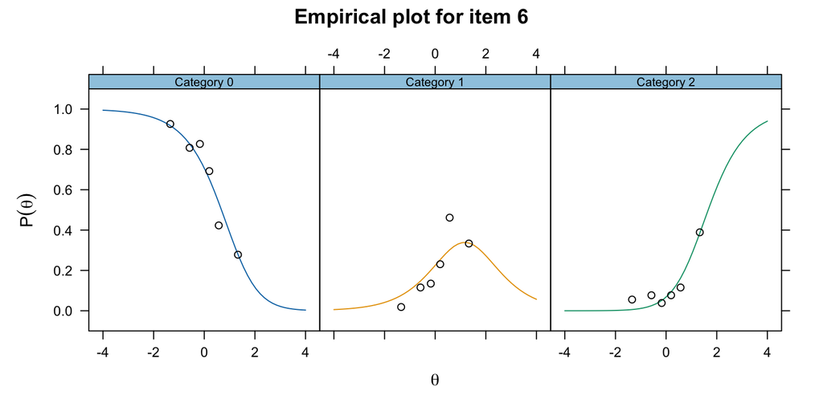

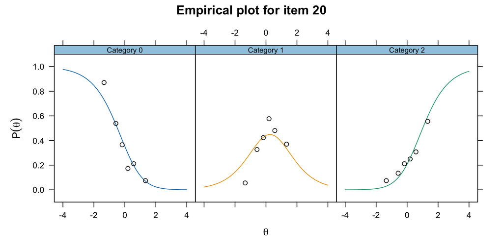

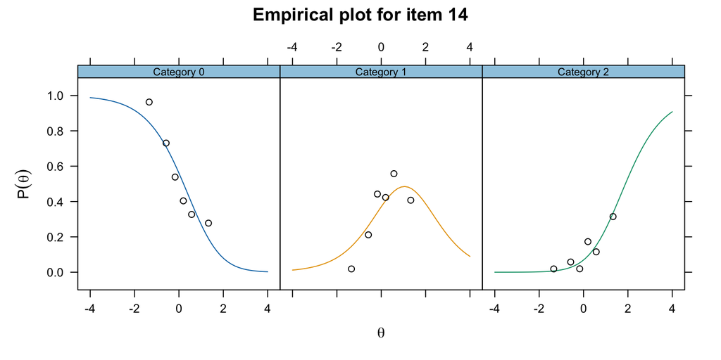

```r
for (it in worst_items) {
  print(
    itemfit(pcm, fit_stats = "PV_Q1", group.bins = 6, method = "EAP",
            empirical.plot = it)
  )
}
```

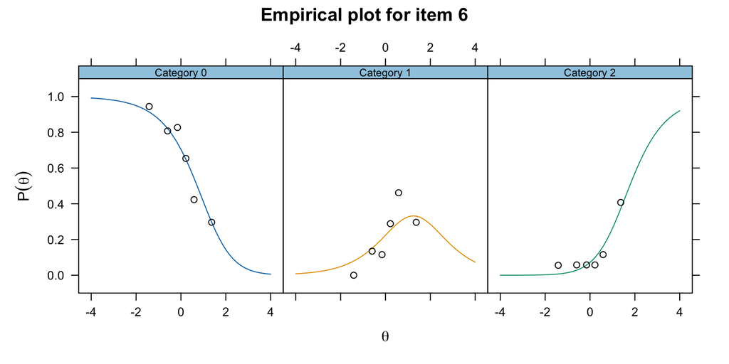

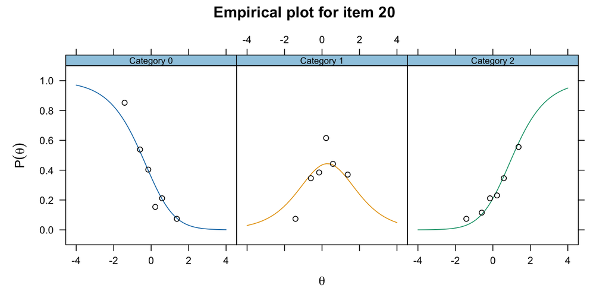

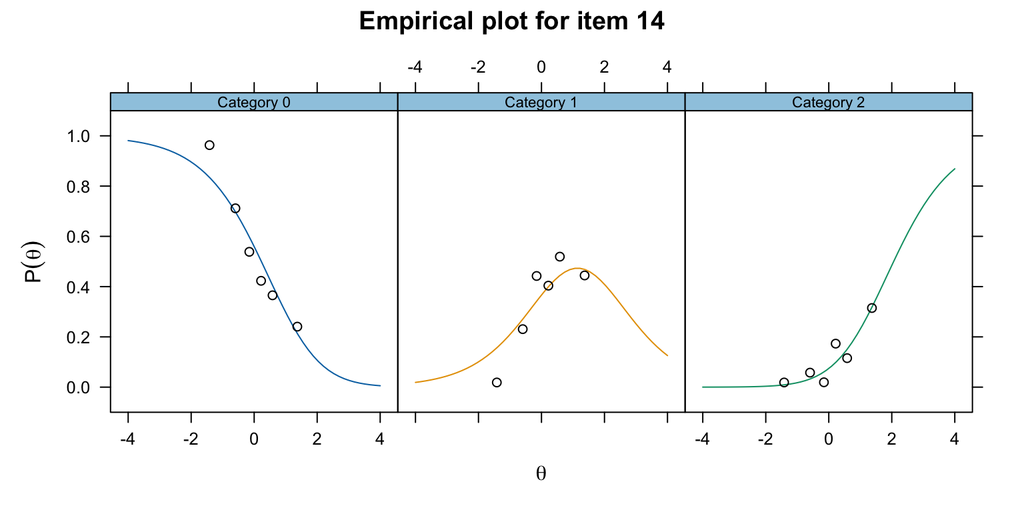

```r
for (it in worst_items) {
  print(
    itemfit(gpcm, fit_stats = "PV_Q1", group.bins = 6, method = "EAP",
            empirical.plot = it)
  )
}
```

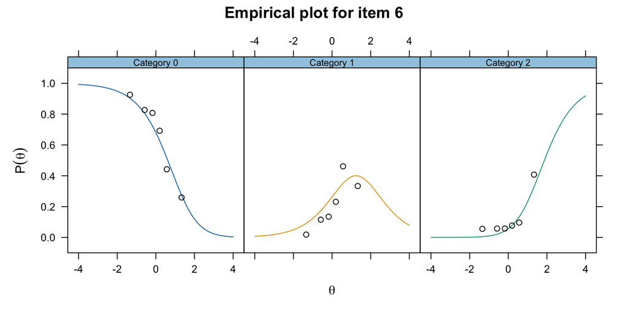

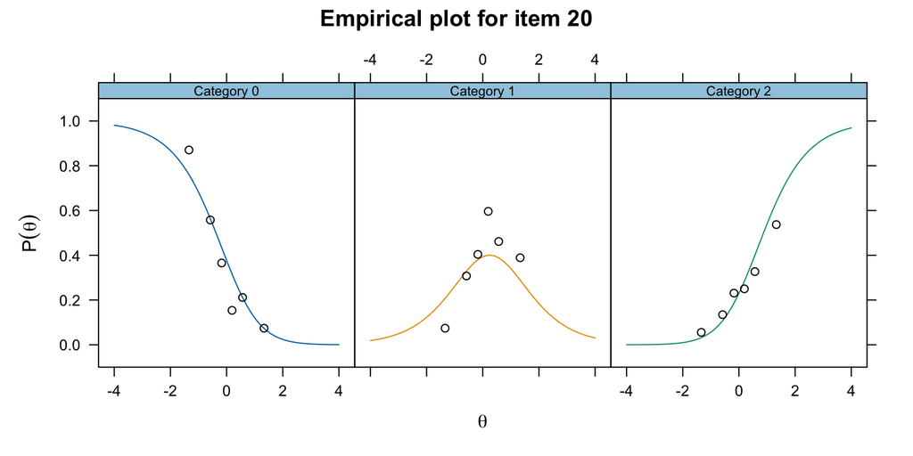

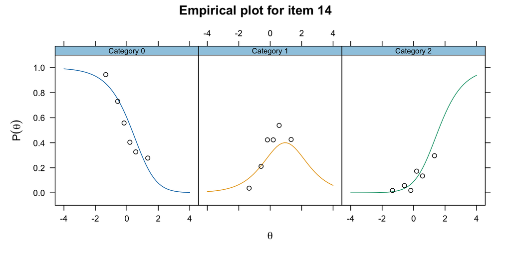

```r
for (it in worst_items) {
  print(
    itemfit(rsm, fit_stats = "PV_Q1", group.bins = 6, method = "EAP",
            empirical.plot = it)
  )
}
```

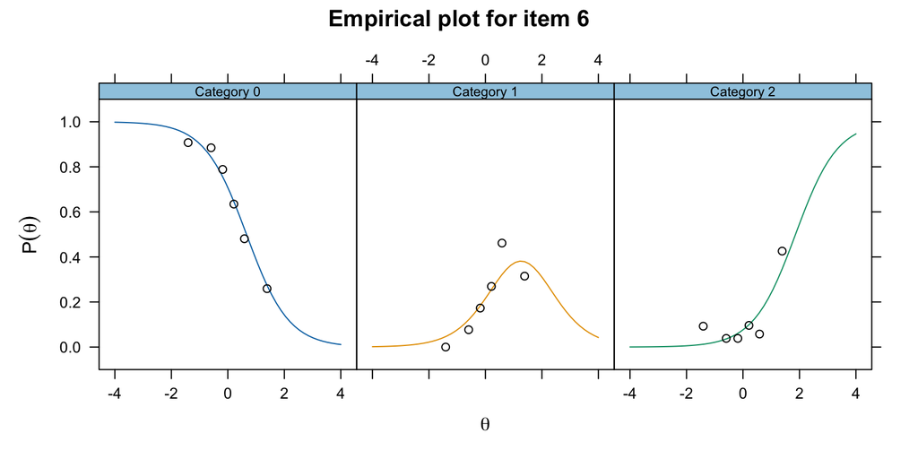

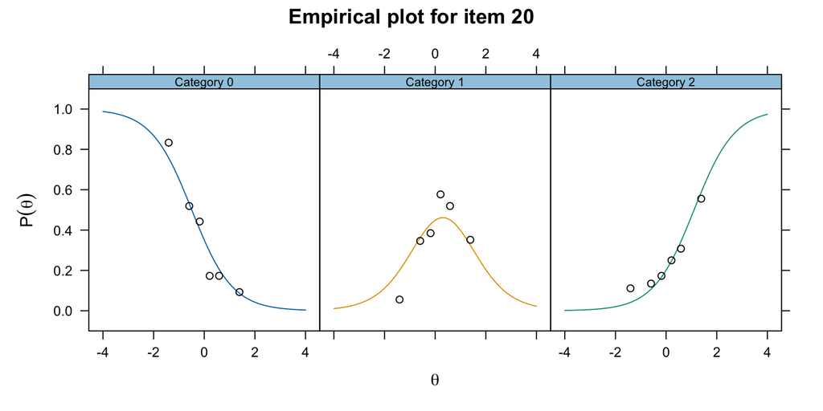

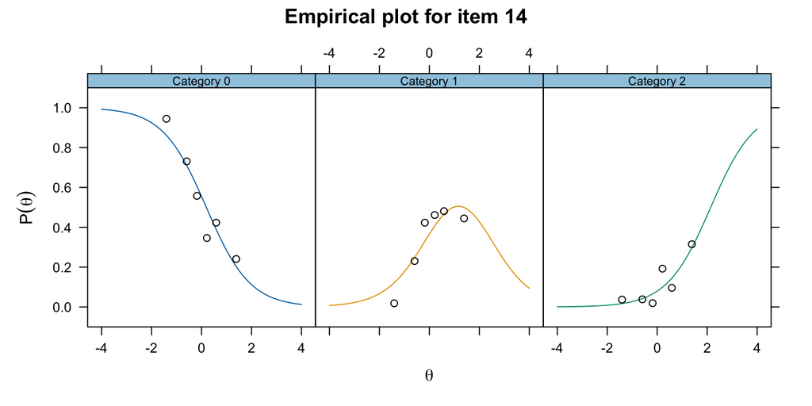

```r
for (it in worst_items) {
  print(
    itemfit(grm, fit_stats = "PV_Q1", group.bins = 6, method = "EAP",
            empirical.plot = it)
  )
}
```

**Interpretation guide**: Look for bins where the observed proportions (points) fall clearly above or below the model-predicted curves. Common patterns of misfit in the verbal aggression data include items where the “perhaps” category is under-used relative to model predictions (consistent with the threshold reversal finding in Q2), or items where the response probabilities are not monotonically related to $\theta$ across all bins.